# EDA Danych dotyczących Irysów

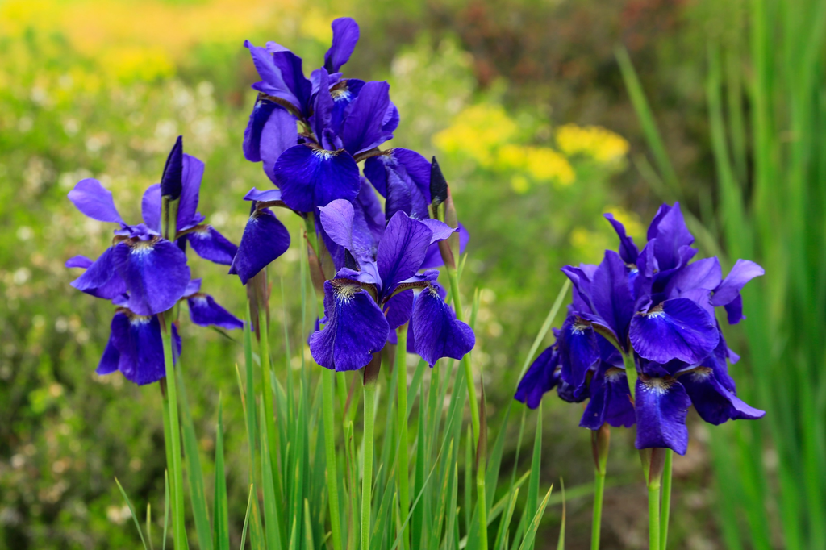

## O Danych

Zbiór danych zawiera informacje o trzech gatunkach irysów: Iris setosa, Iris versicolor, i Iris virginica.

Dane obejmują pomiary czterech cech: długość i szerokość działki kielicha oraz długość i szerokość płatka.

Każdy wiersz w zbiorze danych reprezentuje pojedynczy kwiat, a wartości pomiarów są podane w centymetrach.

Zbiór składa się z 150 próbek, po 50 dla każdego gatunku, i jest szeroko stosowany jako podstawowy zbiór danych do testowania algorytmów klasyfikacji oraz w nauce o danych i uczeniu maszynowym.

Kolumny:

- **długość kielicha (sepal length)** - Długość kielicha w cm
- **szerokość kielicha (sepal width)** - Szerokość kielicha w cm
- **długość płatka (petal length)** - Długość płatka w cm
- **szerokość płatka (petal width)** - Szerokość płatka w cm
- **klasa (class)** - Klasa irysa (setosa, versicolor, virginica)

# 1. IMPORT BBLIOTEK I ZACZYTANIE DANYCH

# 2. PRZEGLAD, ANALIZA I UPORZĄDKOWANIE DANYCH

### Informacje o kolumnach

```
<class 'pandas.core.frame.DataFrame'>
RangeIndex: 150 entries, 0 to 149
Data columns (total 5 columns):
 #   Column                            Non-Null Count  Dtype
---  ------                            --------------  -----
 0   długość kielicha (sepal length)   150 non-null    float64
 1   szerokość kielicha (sepal width)  150 non-null    float64
 2   długość płatka (petal length)     150 non-null    float64
 3   szerokość płatka (petal width)    150 non-null    float64
 4   klasa (class)                     150 non-null    object
dtypes: float64(4), object(1)
memory usage: 6.0+ KB
```

### 10 losowych wierszy

|  | długość kielicha (sepal length) | szerokość kielicha (sepal width) | długość płatka (petal length) | szerokość płatka (petal width) | klasa (class) |
| --- | --- | --- | --- | --- | --- |
| 80 | 5.5 | 2.4 | 3.8 | 1.1 | Iris-versicolor |
| 66 | 5.6 | 3.0 | 4.5 | 1.5 | Iris-versicolor |
| 60 | 5.0 | 2.0 | 3.5 | 1.0 | Iris-versicolor |
| 23 | 5.1 | 3.3 | 1.7 | 0.5 | Iris-setosa |
| 74 | 6.4 | 2.9 | 4.3 | 1.3 | Iris-versicolor |
| 18 | 5.7 | 3.8 | 1.7 | 0.3 | Iris-setosa |
| 64 | 5.6 | 2.9 | 3.6 | 1.3 | Iris-versicolor |
| 94 | 5.6 | 2.7 | 4.2 | 1.3 | Iris-versicolor |
| 70 | 5.9 | 3.2 | 4.8 | 1.8 | Iris-versicolor |
| 13 | 4.3 | 3.0 | 1.1 | 0.1 | Iris-setosa |

- mamy 150 rekordów i 5 kolumn w tabeli
- 4 kolumny numeryczne i jedna typu "object"
- w tabeli nie ma pustych wartości

### Zmiana nazw kolumn

|  | dł. kielicha | szer. kielicha | dł. płatka | szer. płatka | gatunek |
| --- | --- | --- | --- | --- | --- |
| 0 | 5.1 | 3.5 | 1.4 | 0.2 | Iris-setosa |
| 1 | 4.9 | 3.0 | 1.4 | 0.2 | Iris-setosa |
| 2 | 4.7 | 3.2 | 1.3 | 0.2 | Iris-setosa |
| 3 | 4.6 | 3.1 | 1.5 | 0.2 | Iris-setosa |
| 4 | 5.0 | 3.6 | 1.4 | 0.2 | Iris-setosa |

### Zmiana kolejności kolumn

|  | gatunek | dł. kielicha | szer. kielicha | dł. płatka | szer. płatka |
| --- | --- | --- | --- | --- | --- |
| 56 | Iris-versicolor | 6.3 | 3.3 | 4.7 | 1.6 |
| 68 | Iris-versicolor | 6.2 | 2.2 | 4.5 | 1.5 |
| 34 | Iris-setosa | 4.9 | 3.1 | 1.5 | 0.1 |
| 122 | Iris-virginica | 7.7 | 2.8 | 6.7 | 2.0 |
| 105 | Iris-virginica | 7.6 | 3.0 | 6.6 | 2.1 |

### Sprawdzenie unikatów

```
3
```

```
array(['Iris-setosa', 'Iris-versicolor', 'Iris-virginica'], dtype=object)
```

### Komórki puste

```
gatunek           0
dł. kielicha      0
szer. kielicha    0
dł. płatka        0
szer. płatka      0
dtype: int64
```

### Sprawdzenie duplikatów

```
3
```

|  | gatunek | dł. kielicha | szer. kielicha | dł. płatka | szer. płatka |
| --- | --- | --- | --- | --- | --- |
| 34 | Iris-setosa | 4.9 | 3.1 | 1.5 | 0.1 |
| 37 | Iris-setosa | 4.9 | 3.1 | 1.5 | 0.1 |
| 142 | Iris-virginica | 5.8 | 2.7 | 5.1 | 1.9 |

- występują 3 duplikaty. Nie wiadomo, czy zostały zmierzone 3 te same kwiaty, czy w próbie mierzonej pojawiły się osobne kwiaty o takich samych cechach

### Podsumowanie wartości numerycznych

|  | count | mean | std | min | 25% | 50% | 75% | max |
| --- | --- | --- | --- | --- | --- | --- | --- | --- |
| dł. kielicha | 150.0 | 5.84 | 0.83 | 4.3 | 5.1 | 5.80 | 6.4 | 7.9 |
| szer. kielicha | 150.0 | 3.05 | 0.43 | 2.0 | 2.8 | 3.00 | 3.3 | 4.4 |
| dł. płatka | 150.0 | 3.76 | 1.76 | 1.0 | 1.6 | 4.35 | 5.1 | 6.9 |
| szer. płatka | 150.0 | 1.20 | 0.76 | 0.1 | 0.3 | 1.30 | 1.8 | 2.5 |

### Podział na grupy i sprawdzenie ilości pomiarów dla każdej z grup

```
Iris-setosa        50
Iris-versicolor    50
Iris-virginica     50
Name: gatunek, dtype: int64
```

### Sprawdzenie outlierów

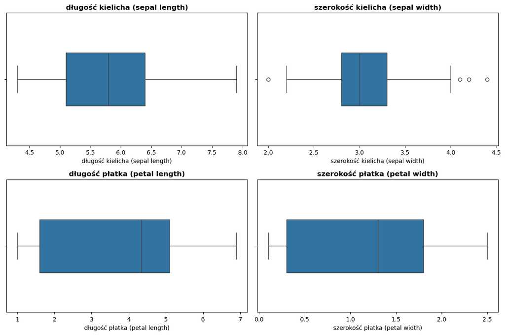

- outliery występują tylko przy pomiarach szerokości kielicha. Należy podjąć decyzję, czy bierzemy je pod uwagę w trakcie analizy, czy pomijamy. W tej analizie wzięto te wielkości do dalszej analizy

## Podsumowanie wstępne

- tabela składa się z 150 wierszy i 5 kolumn
- 4 kolumny typu Float i jedna typu object
- kolumna "gatunek" zawiera 3 rodzaje kwiatów po 50 pomiarów dla każdego rodzaju
- tabela nie zawiera pustych wartości

# 3. ANALIZA

### Porównanie średnich wartości pomiarów - szukanie korelacji

|  | dł. kielicha | szer. kielicha | dł. płatka | szer. płatka |
| --- | --- | --- | --- | --- |
| dł. kielicha | 1.00 | -0.11 | 0.87 | 0.82 |
| szer. kielicha | -0.11 | 1.00 | -0.42 | -0.36 |
| dł. płatka | 0.87 | -0.42 | 1.00 | 0.96 |
| szer. płatka | 0.82 | -0.36 | 0.96 | 1.00 |

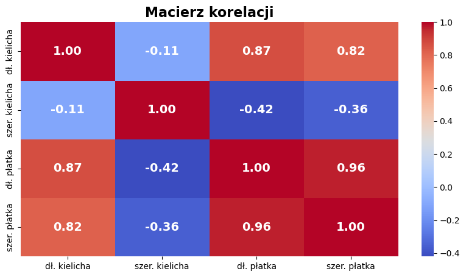

- ujemna korelacja - wraz z przyrostem szerokości kielichów długości i szerokości płatków maleją
- dodatnia korelacja - wraz z przyrostem długości kielichów długości i szerokości płatków zwiększają

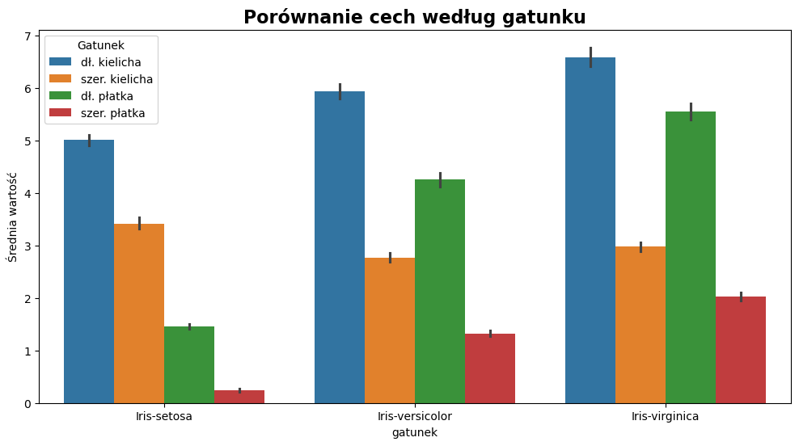

- Iris-setosa przy porównywalnych wielkościach kielichów posiada zdecydowanie mniejsze płatki w stosunku do 2 pozostałych gatunków

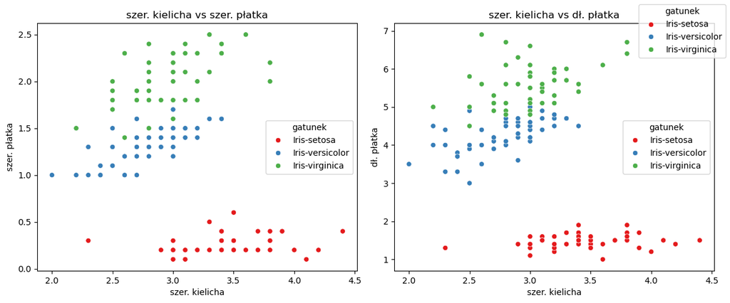

## Porównanie średnich charakterystyk po klasach

```
klasa (class)                     Iris-setosa  Iris-versicolor  Iris-virginica
długość kielicha (sepal length)         5.006            5.936           6.588
szerokość kielicha (sepal width)        3.418            2.770           2.974
długość płatka (petal length)           1.464            4.260           5.552
szerokość płatka (petal width)          0.244            1.326           2.026
```

#### Odchylenie średnich charakterystyk względem Iris-setosa

```
klasa (class)                     Iris-setosa  Iris-versicolor  Iris-virginica
długość kielicha (sepal length)           1.0            1.186           1.316
szerokość kielicha (sepal width)          1.0            0.810           0.870
długość płatka (petal length)             1.0            2.910           3.792
szerokość płatka (petal width)            1.0            5.434           8.303
```

#### Iris-setosa przy porównywalnych kielichach ma zdecydowanie mniejsze płatki od pozostałych klas.

# 5. WNIOSKI KOŃCOWE